```python
import pandas as pd
import numpy as np
import matplotlib.pyplot as plt
import seaborn as sns
```

# Investigating Happiness

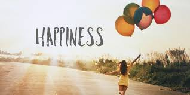

```
                                 **" A Smile is a curve that sets everything straight!!"**
```

# Problem statement:

Building a model to determine the most important factors in day-to-day life that makes a person happy.

# Attributes:

1. Country : Name of the country
1. Region : Region the country belongs to
1. Happiness Rank : Rank of the country based on the Happiness Score
1. Happiness Score : A metric measured in 2015 by asking the sampled people the question: "How would you rate your happiness on a scale of 0 to 10 where 10 is the happiest."
1. Standard Error : The standard error of the happiness score.
1. Economy (GDP per Capita) : The extent to which GDP contributes to the calculation of the Happiness Score.
1. Family : The extent to which Family contributes to the calculation of the Happiness Score
1. Health (Life Expectancy) : The extent to which Life expectancy contributed to the calculation of the Happiness Score
1. Freedom : The extent to which Freedom contributed to the calculation of the Happiness Score.
1. Trust (Government Corruption) : The extent to which Perception of Corruption contributes to Happiness Score.
1. Generosity : The extent to which Generosity contributed to the calculation of the Happiness Score.
1. Dystopia Residual : The extent to which Dystopia Residual contributed to the calculation of the Happiness Score.

```python
df = pd.read_csv(r'C:\Users\krish\Downloads\world-happiness\2015.csv')
```

```python
df1 = pd.read_csv(r'C:\Users\krish\Downloads\world-happiness\2016.csv')
```

```python
df2 = pd.read_csv(r'C:\Users\krish\Downloads\world-happiness\2017.csv')
```

```python
df.head()
```

|  | Country | Region | Happiness Rank | Happiness Score | Standard Error | Economy (GDP per Capita) | Family | Health (Life Expectancy) | Freedom | Trust (Government Corruption) | Generosity | Dystopia Residual |
| --- | --- | --- | --- | --- | --- | --- | --- | --- | --- | --- | --- | --- |
| 0 | Switzerland | Western Europe | 1 | 7.587 | 0.03411 | 1.39651 | 1.34951 | 0.94143 | 0.66557 | 0.41978 | 0.29678 | 2.51738 |
| 1 | Iceland | Western Europe | 2 | 7.561 | 0.04884 | 1.30232 | 1.40223 | 0.94784 | 0.62877 | 0.14145 | 0.43630 | 2.70201 |
| 2 | Denmark | Western Europe | 3 | 7.527 | 0.03328 | 1.32548 | 1.36058 | 0.87464 | 0.64938 | 0.48357 | 0.34139 | 2.49204 |
| 3 | Norway | Western Europe | 4 | 7.522 | 0.03880 | 1.45900 | 1.33095 | 0.88521 | 0.66973 | 0.36503 | 0.34699 | 2.46531 |
| 4 | Canada | North America | 5 | 7.427 | 0.03553 | 1.32629 | 1.32261 | 0.90563 | 0.63297 | 0.32957 | 0.45811 | 2.45176 |

This is how the 2015 data looks like.

# What do the columns succeeding the Happiness Score(like Family, Generosity, etc.) describe?

**The columns:** GDP per Capita, Family, Life Expectancy, Freedom, Generosity, Trust Government Corruption - describe the extent to which these factors contribute in evaluating the happiness in each country.

**What is Dystopia?**

- Dystopia is an imaginary country that has the **world’s least-happy people.** The purpose in establishing Dystopia is to have a benchmark against which all countries can be favorably compared (no country performs more poorly than Dystopia) in terms of each of the six key variables, thus allowing each sub-bar to be of positive width. The lowest scores observed for the six key variables, therefore, characterize Dystopia.
- Since life would be very unpleasant in a country with the world’s lowest incomes, lowest life expectancy, lowest generosity, most corruption, least freedom and least social support, it is referred to as “Dystopia,” in contrast to Utopia.

```python
Happy = df[['Country', 'Happiness Rank','Happiness Score']].sort_values(by = 'Happiness Rank', ascending = True).head(10)
```

```python
Happy
```

|  | Country | Happiness Rank | Happiness Score |
| --- | --- | --- | --- |
| 0 | Switzerland | 1 | 7.587 |
| 1 | Iceland | 2 | 7.561 |
| 2 | Denmark | 3 | 7.527 |
| 3 | Norway | 4 | 7.522 |
| 4 | Canada | 5 | 7.427 |
| 5 | Finland | 6 | 7.406 |
| 6 | Netherlands | 7 | 7.378 |
| 7 | Sweden | 8 | 7.364 |
| 8 | New Zealand | 9 | 7.286 |
| 9 | Australia | 10 | 7.284 |

These are the Top 10 happy countries in 2015.

Switzerland is the happiest country with the score of 7.587

```python
df.iloc[:,[0,1,2,3]].sort_values(by = 'Happiness Rank', ascending = False).head(10)
```

|  | Country | Region | Happiness Rank | Happiness Score |
| --- | --- | --- | --- | --- |
| 157 | Togo | Sub-Saharan Africa | 158 | 2.839 |
| 156 | Burundi | Sub-Saharan Africa | 157 | 2.905 |
| 155 | Syria | Middle East and Northern Africa | 156 | 3.006 |
| 154 | Benin | Sub-Saharan Africa | 155 | 3.340 |
| 153 | Rwanda | Sub-Saharan Africa | 154 | 3.465 |
| 152 | Afghanistan | Southern Asia | 153 | 3.575 |
| 151 | Burkina Faso | Sub-Saharan Africa | 152 | 3.587 |
| 150 | Ivory Coast | Sub-Saharan Africa | 151 | 3.655 |
| 149 | Guinea | Sub-Saharan Africa | 150 | 3.656 |
| 148 | Chad | Sub-Saharan Africa | 149 | 3.667 |

In 2015, these are the countries with lowest Happiness Index with Togo at the top.

```python
df['Region'].unique()
```

```
array(['Western Europe', 'North America', 'Australia and New Zealand',
       'Middle East and Northern Africa', 'Latin America and Caribbean',
       'Southeastern Asia', 'Central and Eastern Europe', 'Eastern Asia',
       'Sub-Saharan Africa', 'Southern Asia'], dtype=object)
```

```python
df['Region'].describe(include = 'all')
```

```
count                    158
unique                    10
top       Sub-Saharan Africa
freq                      40
Name: Region, dtype: object
```

The 158 countries are located in 10 different regions.

# Region-wise Scores

```python
import plotly.express as px
#df_a = px.df.query(" == 'Canada'")
fig = px.bar(df, x='Region', y='Happiness Score')
fig.show()
```

[interactive chart not shown]

From the above graph, we can see that most countries belongs to the following 3 regions:

1. Sub-Saharan Africa
2. Central and Eastern Europe
3. Western Europe

# Sub-Saharan Africa

We will observe the major factors impacting to the index.

```python
e = df.loc[lambda df: df['Region'] == 'Sub-Saharan Africa']
e.head(2)
```

|  | Country | Region | Happiness Rank | Happiness Score | Standard Error | Economy (GDP per Capita) | Family | Health (Life Expectancy) | Freedom | Trust (Government Corruption) | Generosity | Dystopia Residual |
| --- | --- | --- | --- | --- | --- | --- | --- | --- | --- | --- | --- | --- |
| 70 | Mauritius | Sub-Saharan Africa | 71 | 5.477 | 0.07197 | 1.00761 | 0.98521 | 0.70950 | 0.56066 | 0.07521 | 0.37744 | 1.76145 |
| 77 | Nigeria | Sub-Saharan Africa | 78 | 5.268 | 0.04192 | 0.65435 | 0.90432 | 0.16007 | 0.34334 | 0.04030 | 0.27233 | 2.89319 |

```python
e.describe(include = 'all').T
```

|  | count | unique | top | freq | mean | std | min | 25% | 50% | 75% | max |
| --- | --- | --- | --- | --- | --- | --- | --- | --- | --- | --- | --- |
| Country | 40 | 40 | Djibouti | 1 | NaN | NaN | NaN | NaN | NaN | NaN | NaN |
| Region | 40 | 1 | Sub-Saharan Africa | 40 | NaN | NaN | NaN | NaN | NaN | NaN | NaN |
| Happiness Rank | 40 | NaN | NaN | NaN | 127.9 | 22.8639 | 71 | 115.75 | 132 | 146.25 | 158 |
| Happiness Score | 40 | NaN | NaN | NaN | 4.2028 | 0.609557 | 2.839 | 3.756 | 4.272 | 4.58075 | 5.477 |
| Standard Error | 40 | NaN | NaN | NaN | 0.0552987 | 0.0187568 | 0.03464 | 0.0413075 | 0.047775 | 0.0673025 | 0.11068 |
| Economy (GDP per Capita) | 40 | NaN | NaN | NaN | 0.380473 | 0.282264 | 0 | 0.203863 | 0.308445 | 0.483052 | 1.06024 |
| Family | 40 | NaN | NaN | NaN | 0.809085 | 0.267819 | 0 | 0.676657 | 0.878375 | 1.00157 | 1.18468 |
| Health (Life Expectancy) | 40 | NaN | NaN | NaN | 0.282332 | 0.145906 | 0 | 0.16514 | 0.298155 | 0.372122 | 0.7095 |
| Freedom | 40 | NaN | NaN | NaN | 0.365944 | 0.120693 | 0.10081 | 0.301262 | 0.38291 | 0.46201 | 0.59201 |
| Trust (Government Corruption) | 40 | NaN | NaN | NaN | 0.123878 | 0.0969412 | 0.0306 | 0.0723075 | 0.103875 | 0.13289 | 0.55191 |
| Generosity | 40 | NaN | NaN | NaN | 0.221137 | 0.0809119 | 0.06822 | 0.182598 | 0.207305 | 0.243342 | 0.50318 |
| Dystopia Residual | 40 | NaN | NaN | NaN | 2.01998 | 0.553476 | 0.67042 | 1.66933 | 1.95005 | 2.45826 | 3.05137 |

```python
import plotly.express as px
#df_a = px.df.query(" == 'Canada'")
fig = px.bar(e, x='Country', y='Happiness Score')
fig.show()
```

[interactive chart not shown]

Out of 158 countries, 40 countries are from Sub-Saharan Africa region with the average Happiness Score of 4.2028

We can observe that Mauritius with the rank 71 and score 5.477 is the happiest in the region.

Togo is the most unhappy with rank 158 and score 2.839

```python
import plotly.express as px
df.query("Region=='Sub-Saharan Africa'")
fig = px.line(df, x="Happiness Score", y="Trust (Government Corruption)", title='Sub-Saharan Africa')
fig.show()
```

[interactive chart not shown]

The above graph shows that the population of this region doesn't really trusts the Government.

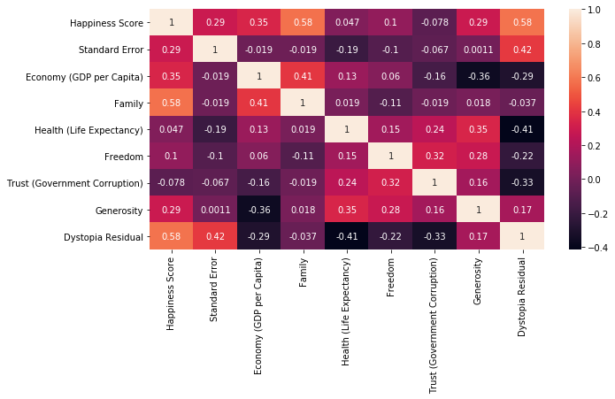

```python
e_1 = e.drop('Happiness Rank' , axis = 'columns')
hm = e_1.corr()
fig, ax = plt.subplots(figsize=(10,5))
sns.heatmap(hm , annot=True, ax=ax)
plt.show();
```

From the heatmap we can infer the following:

1. People are satisfied and happy with their **Famlies**.
2. **Economy** plays a significant role in their happiness.
3. But, people have no faith in their Government as we can see that it is negatively correlated with the score.

# Central and Eastern Europe

```python
f = df.loc[lambda df: df['Region'] == 'Central and Eastern Europe']
f.head(2)
```

|  | Country | Region | Happiness Rank | Happiness Score | Standard Error | Economy (GDP per Capita) | Family | Health (Life Expectancy) | Freedom | Trust (Government Corruption) | Generosity | Dystopia Residual |
| --- | --- | --- | --- | --- | --- | --- | --- | --- | --- | --- | --- | --- |
| 30 | Czech Republic | Central and Eastern Europe | 31 | 6.505 | 0.04168 | 1.17898 | 1.20643 | 0.84483 | 0.46364 | 0.02652 | 0.10686 | 2.67782 |
| 43 | Uzbekistan | Central and Eastern Europe | 44 | 6.003 | 0.04361 | 0.63244 | 1.34043 | 0.59772 | 0.65821 | 0.30826 | 0.22837 | 2.23741 |

```python
f.describe(include='all').T
```

|  | count | unique | top | freq | mean | std | min | 25% | 50% | 75% | max |
| --- | --- | --- | --- | --- | --- | --- | --- | --- | --- | --- | --- |
| Country | 29 | 29 | Kosovo | 1 | NaN | NaN | NaN | NaN | NaN | NaN | NaN |
| Region | 29 | 1 | Central and Eastern Europe | 29 | NaN | NaN | NaN | NaN | NaN | NaN | NaN |
| Happiness Rank | 29 | NaN | NaN | NaN | 79 | 26.6673 | 31 | 59 | 77 | 95 | 134 |
| Happiness Score | 29 | NaN | NaN | NaN | 5.33293 | 0.570446 | 4.218 | 4.959 | 5.286 | 5.813 | 6.505 |
| Standard Error | 29 | NaN | NaN | NaN | 0.0452076 | 0.00895204 | 0.03135 | 0.04013 | 0.04267 | 0.04864 | 0.06913 |
| Economy (GDP per Capita) | 29 | NaN | NaN | NaN | 0.942438 | 0.218499 | 0.39047 | 0.80148 | 1.01216 | 1.12254 | 1.18498 |
| Family | 29 | NaN | NaN | NaN | 1.05304 | 0.217005 | 0.38562 | 0.90557 | 1.10614 | 1.22791 | 1.34043 |
| Health (Life Expectancy) | 29 | NaN | NaN | NaN | 0.718774 | 0.0813386 | 0.53886 | 0.65088 | 0.73128 | 0.77361 | 0.87337 |
| Freedom | 29 | NaN | NaN | NaN | 0.358269 | 0.130925 | 0.09245 | 0.25883 | 0.35068 | 0.44888 | 0.65821 |
| Trust (Government Corruption) | 29 | NaN | NaN | NaN | 0.0866738 | 0.100134 | 0.00227 | 0.02652 | 0.04212 | 0.14296 | 0.38331 |
| Generosity | 29 | NaN | NaN | NaN | 0.152264 | 0.0759547 | 0.00199 | 0.10686 | 0.15275 | 0.20951 | 0.3003 |
| Dystopia Residual | 29 | NaN | NaN | NaN | 2.0214 | 0.468624 | 0.89991 | 1.73933 | 2.025 | 2.24639 | 3.10712 |

```python
import plotly.express as px
fig = px.bar(f, x='Country', y='Happiness Score')
fig.show()
```

[interactive chart not shown]

Out of 158 countries, 29 are from Central and Eastern Europe with the average happiness score of 5.33293

From the above graph, we can see the ranks of all the countries present in this region

Czech Republic is the happiest in this region with the rank 31 and score 6.505

```python
import plotly.express as px
df.query("Region=='Central and Eastern Europe'")
fig = px.line(f, x="Happiness Score", y="Family", title='Central and Eastern Europe')
fig.show()
```

[interactive chart not shown]

Family has a positive impact on happiness.

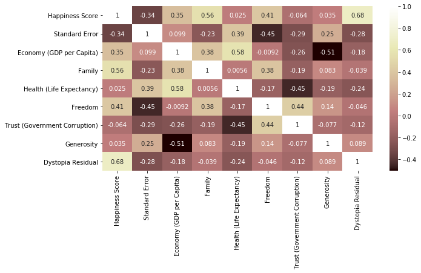

```python
f_1 = f.drop('Happiness Rank' , axis = 'columns')
hm = f_1.corr()
fig, ax = plt.subplots(figsize=(10,5))
sns.heatmap(hm , annot=True, ax=ax, cmap='pink')
plt.show();
```

Family and Freedom has a greater impact on the Happiness of people. While, Economy also has relatively less impact.

People really don't trust their government as it is negatively correlated.

# Western Europe

Now we will see what are the major factors that impact the happiness index in Europe.

```python
d = df.loc[lambda df: df['Region'] == 'Western Europe']
```

```python
d.head(5)
```

|  | Country | Region | Happiness Rank | Happiness Score | Standard Error | Economy (GDP per Capita) | Family | Health (Life Expectancy) | Freedom | Trust (Government Corruption) | Generosity | Dystopia Residual |
| --- | --- | --- | --- | --- | --- | --- | --- | --- | --- | --- | --- | --- |
| 0 | Switzerland | Western Europe | 1 | 7.587 | 0.03411 | 1.39651 | 1.34951 | 0.94143 | 0.66557 | 0.41978 | 0.29678 | 2.51738 |
| 1 | Iceland | Western Europe | 2 | 7.561 | 0.04884 | 1.30232 | 1.40223 | 0.94784 | 0.62877 | 0.14145 | 0.43630 | 2.70201 |
| 2 | Denmark | Western Europe | 3 | 7.527 | 0.03328 | 1.32548 | 1.36058 | 0.87464 | 0.64938 | 0.48357 | 0.34139 | 2.49204 |
| 3 | Norway | Western Europe | 4 | 7.522 | 0.03880 | 1.45900 | 1.33095 | 0.88521 | 0.66973 | 0.36503 | 0.34699 | 2.46531 |
| 5 | Finland | Western Europe | 6 | 7.406 | 0.03140 | 1.29025 | 1.31826 | 0.88911 | 0.64169 | 0.41372 | 0.23351 | 2.61955 |

```python
d.describe(include = 'all').T
```

|  | count | unique | top | freq | mean | std | min | 25% | 50% | 75% | max |
| --- | --- | --- | --- | --- | --- | --- | --- | --- | --- | --- | --- |
| Country | 21 | 21 | North Cyprus | 1 | NaN | NaN | NaN | NaN | NaN | NaN | NaN |
| Region | 21 | 1 | Western Europe | 21 | NaN | NaN | NaN | NaN | NaN | NaN | NaN |
| Happiness Rank | 21 | NaN | NaN | NaN | 29.5238 | 29.2688 | 1 | 7 | 19 | 37 | 102 |
| Happiness Score | 21 | NaN | NaN | NaN | 6.68962 | 0.824582 | 4.857 | 6.302 | 6.937 | 7.378 | 7.587 |
| Standard Error | 21 | NaN | NaN | NaN | 0.0376252 | 0.0101443 | 0.01848 | 0.03328 | 0.03595 | 0.04206 | 0.05635 |
| Economy (GDP per Capita) | 21 | NaN | NaN | NaN | 1.2986 | 0.0963411 | 1.15406 | 1.23011 | 1.30232 | 1.33171 | 1.56391 |
| Family | 21 | NaN | NaN | NaN | 1.2473 | 0.135195 | 0.89318 | 1.21963 | 1.28907 | 1.31826 | 1.40223 |
| Health (Life Expectancy) | 21 | NaN | NaN | NaN | 0.909148 | 0.0268337 | 0.87464 | 0.88911 | 0.89667 | 0.92356 | 0.95562 |
| Freedom | 21 | NaN | NaN | NaN | 0.549926 | 0.147211 | 0.07699 | 0.51469 | 0.61477 | 0.62877 | 0.66973 |
| Trust (Government Corruption) | 21 | NaN | NaN | NaN | 0.231463 | 0.150801 | 0.01078 | 0.13586 | 0.21843 | 0.36503 | 0.48357 |
| Generosity | 21 | NaN | NaN | NaN | 0.302109 | 0.133845 | 0 | 0.22823 | 0.29678 | 0.36262 | 0.51912 |
| Dystopia Residual | 21 | NaN | NaN | NaN | 2.15119 | 0.379951 | 1.26462 | 1.96961 | 2.12367 | 2.4657 | 2.70201 |

Out of 158 countries in total, 21 countries are from Western Europe with the average Happiness Score of 6.68962

```python
import plotly.express as px
#df_a = px.df.query(" == 'Canada'")
fig = px.bar(d, x='Country', y='Happiness Score')
fig.show()
```

[interactive chart not shown]

From above graph we can observe the following:

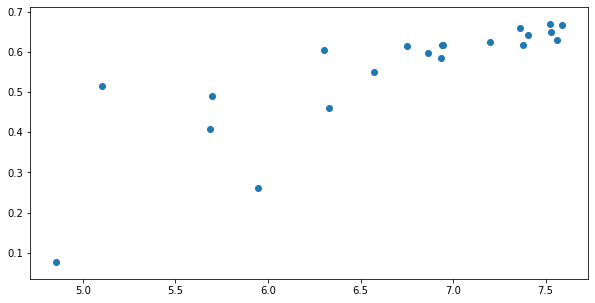

```python
x_2 = [x for x in d['Happiness Score']]

y_2 = [y  for y in d['Freedom']]
import matplotlib.pyplot as plot
plot.scatter(x_2, y_2)
```

People are really enjoying their freedom in this region.

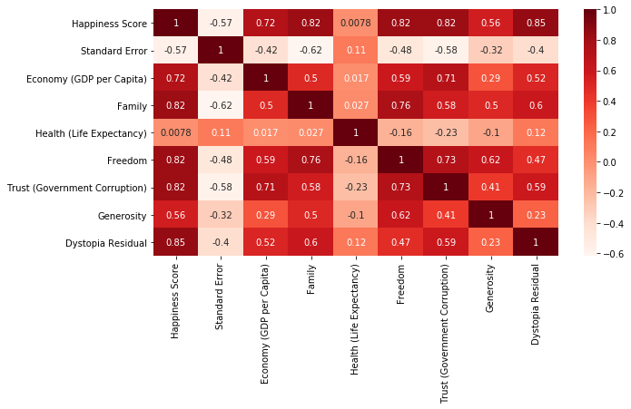

```python
d_1 = d.drop('Happiness Rank' , axis = 'columns')
hm = d_1.corr()
fig, ax = plt.subplots(figsize=(10,5))
sns.heatmap(hm , annot=True, ax=ax, cmap='Reds')
plt.show();
```

From the above Heatmap, we can infer that people in Europe have Trust in Government, enjoys their freedom and are happy with their families. Also, it is positively correlated with Economy and Generosity.

Western Europe is a Happy Continent.

# India

Now we'll look at India which falls in the Southern Asian Region.

```python
g = df.loc[lambda df: df['Region'] == 'Southern Asia']
```

```python
import plotly.express as px
fig = px.bar(g, x='Country', y='Happiness Score')
fig.show()
```

[interactive chart not shown]

```python
g.query('Country == "India"')
```

|  | Country | Region | Happiness Rank | Happiness Score | Standard Error | Economy (GDP per Capita) | Family | Health (Life Expectancy) | Freedom | Trust (Government Corruption) | Generosity | Dystopia Residual |
| --- | --- | --- | --- | --- | --- | --- | --- | --- | --- | --- | --- | --- |
| 116 | India | Southern Asia | 117 | 4.565 | 0.02043 | 0.64499 | 0.38174 | 0.51529 | 0.39786 | 0.08492 | 0.26475 | 2.27513 |

From the table above, we can see that Economy and Health has the major impact on Happiness of mankind.

Family & Freedom also has some impact but People of India really doesn't trust their government.

# Conclusion for the year 2015

Now we'll look at the major factors impacting the happiness around the globe.

```python
df.describe(include = 'all').T
```

|  | count | unique | top | freq | mean | std | min | 25% | 50% | 75% | max |
| --- | --- | --- | --- | --- | --- | --- | --- | --- | --- | --- | --- |
| Country | 158 | 158 | Peru | 1 | NaN | NaN | NaN | NaN | NaN | NaN | NaN |
| Region | 158 | 10 | Sub-Saharan Africa | 40 | NaN | NaN | NaN | NaN | NaN | NaN | NaN |
| Happiness Rank | 158 | NaN | NaN | NaN | 79.4937 | 45.7544 | 1 | 40.25 | 79.5 | 118.75 | 158 |
| Happiness Score | 158 | NaN | NaN | NaN | 5.37573 | 1.14501 | 2.839 | 4.526 | 5.2325 | 6.24375 | 7.587 |
| Standard Error | 158 | NaN | NaN | NaN | 0.0478847 | 0.0171462 | 0.01848 | 0.0372675 | 0.04394 | 0.0523 | 0.13693 |
| Economy (GDP per Capita) | 158 | NaN | NaN | NaN | 0.846137 | 0.403121 | 0 | 0.545808 | 0.910245 | 1.15845 | 1.69042 |
| Family | 158 | NaN | NaN | NaN | 0.991046 | 0.272369 | 0 | 0.856823 | 1.02951 | 1.2144 | 1.40223 |
| Health (Life Expectancy) | 158 | NaN | NaN | NaN | 0.630259 | 0.247078 | 0 | 0.439185 | 0.696705 | 0.811013 | 1.02525 |
| Freedom | 158 | NaN | NaN | NaN | 0.428615 | 0.150693 | 0 | 0.32833 | 0.435515 | 0.549092 | 0.66973 |
| Trust (Government Corruption) | 158 | NaN | NaN | NaN | 0.143422 | 0.120034 | 0 | 0.061675 | 0.10722 | 0.180255 | 0.55191 |
| Generosity | 158 | NaN | NaN | NaN | 0.237296 | 0.126685 | 0 | 0.150553 | 0.21613 | 0.309883 | 0.79588 |
| Dystopia Residual | 158 | NaN | NaN | NaN | 2.09898 | 0.55355 | 0.32858 | 1.75941 | 2.09542 | 2.46241 | 3.60214 |

From the above table we observe the following:

1. The World Happiness Report 2015, has ranked 158 countries by their happiness levels.
2. The highest happiness score is 7.587 while the lowest is 2.839.

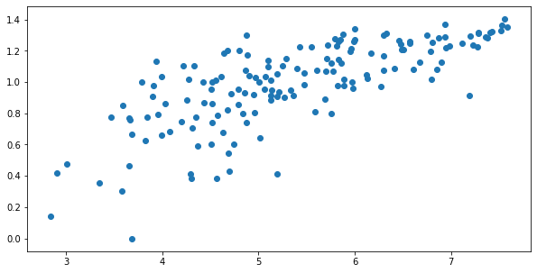

```python
x_2 = [x for x in df['Happiness Score']]

y_2 = [y  for y in df['Family']]
import matplotlib.pyplot as plot
plot.scatter(x_2, y_2)
```

Family has a major impact on happiness.

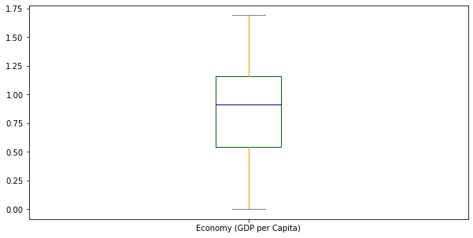

```python
color = dict(boxes='DarkGreen', whiskers='DarkOrange',medians='DarkBlue', caps='Gray')
df['Economy (GDP per Capita)'].plot.box(color = color , sym = 'r+')
plt.show()
```

Economy also plays a major role in happiness.

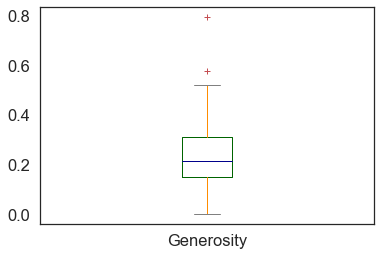

```python
color = dict(boxes='DarkGreen', whiskers='DarkOrange',medians='DarkBlue', caps='Gray')
df['Generosity'].plot.box(color = color , sym = 'r+')
plt.show()
```

Generosity really doesn't contribute much to the happiness index.

```python
import matplotlib.pyplot as plt
import seaborn as sns
```

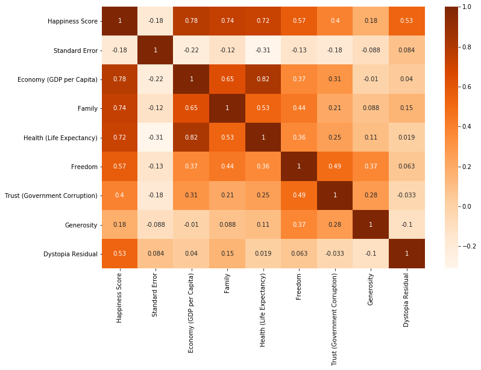

```python
a = df.drop('Happiness Rank' , axis = 'columns')
hm = a.corr()
fig, ax = plt.subplots(figsize=(12,8))
sns.heatmap(hm , annot=True, ax=ax, cmap='Oranges')

plt.show();
```

# World Happiness Index for the year 2015, 2016, 2017

Comparison between the 3 years

```python
Happy1 = df1[['Country', 'Happiness Rank','Happiness Score']].sort_values(by = 'Happiness Rank', ascending = True).head(10)
```

```python
Happy1
```

|  | Country | Happiness Rank | Happiness Score |
| --- | --- | --- | --- |
| 0 | Denmark | 1 | 7.526 |
| 1 | Switzerland | 2 | 7.509 |
| 2 | Iceland | 3 | 7.501 |
| 3 | Norway | 4 | 7.498 |
| 4 | Finland | 5 | 7.413 |
| 5 | Canada | 6 | 7.404 |
| 6 | Netherlands | 7 | 7.339 |
| 7 | New Zealand | 8 | 7.334 |
| 8 | Australia | 9 | 7.313 |
| 9 | Sweden | 10 | 7.291 |

Top 10 countries for the year 2016.

```python
Happy2 = df2[['Country', 'Happiness.Rank','Happiness.Score']].sort_values(by = 'Happiness.Rank', ascending = True).head(10)
```

```python
Happy2
```

|  | Country | Happiness.Rank | Happiness.Score |
| --- | --- | --- | --- |
| 0 | Norway | 1 | 7.537 |
| 1 | Denmark | 2 | 7.522 |
| 2 | Iceland | 3 | 7.504 |
| 3 | Switzerland | 4 | 7.494 |
| 4 | Finland | 5 | 7.469 |
| 5 | Netherlands | 6 | 7.377 |
| 6 | Canada | 7 | 7.316 |
| 7 | New Zealand | 8 | 7.314 |
| 8 | Sweden | 9 | 7.284 |
| 9 | Australia | 10 | 7.284 |

Top 10 countries for the year 2017.

```python
m = pd.concat([Happy, Happy1], axis=1)
```

```python
n = pd.concat([m,Happy2], axis=1)
```

```python
n
```

|  | Country | Happiness Rank | Happiness Score | Country | Happiness Rank | Happiness Score | Country | Happiness.Rank | Happiness.Score |
| --- | --- | --- | --- | --- | --- | --- | --- | --- | --- |
| 0 | Switzerland | 1 | 7.587 | Denmark | 1 | 7.526 | Norway | 1 | 7.537 |
| 1 | Iceland | 2 | 7.561 | Switzerland | 2 | 7.509 | Denmark | 2 | 7.522 |
| 2 | Denmark | 3 | 7.527 | Iceland | 3 | 7.501 | Iceland | 3 | 7.504 |
| 3 | Norway | 4 | 7.522 | Norway | 4 | 7.498 | Switzerland | 4 | 7.494 |
| 4 | Canada | 5 | 7.427 | Finland | 5 | 7.413 | Finland | 5 | 7.469 |
| 5 | Finland | 6 | 7.406 | Canada | 6 | 7.404 | Netherlands | 6 | 7.377 |
| 6 | Netherlands | 7 | 7.378 | Netherlands | 7 | 7.339 | Canada | 7 | 7.316 |
| 7 | Sweden | 8 | 7.364 | New Zealand | 8 | 7.334 | New Zealand | 8 | 7.314 |
| 8 | New Zealand | 9 | 7.286 | Australia | 9 | 7.313 | Sweden | 9 | 7.284 |
| 9 | Australia | 10 | 7.284 | Sweden | 10 | 7.291 | Australia | 10 | 7.284 |